# Exercise Form Prediction Analysis

Jacob Robinson

2025-06-02

## Introduction

This analysis aims to predict the manner in which participants performed barbell lifts using data from accelerometers placed on different parts of their bodies. The goal is to build a machine learning model that can accurately classify the exercise form into one of five categories.

## Data Loading and Preprocessing

```r
library(tidyverse)
library(caret)
library(randomForest)
library(rpart)
library(rpart.plot)
library(corrplot)
```

```r
# Load the training and testing datasets
training <- read.csv("pml-training.csv")
testing <- read.csv("pml-testing.csv")

# Remove columns with mostly NA values
na_cols <- colSums(is.na(training)) > 0.5 * nrow(training)
training <- training[, !na_cols]
testing <- testing[, !na_cols]

# Remove non-predictive columns
training <- training %>%
  select(-c(X, user_name, raw_timestamp_part_1, raw_timestamp_part_2,
            cvtd_timestamp, new_window, num_window))

testing <- testing %>%
  select(-c(X, user_name, raw_timestamp_part_1, raw_timestamp_part_2,
            cvtd_timestamp, new_window, num_window))

# Convert classe to factor
training$classe <- as.factor(training$classe)
```

## Exploratory Data Analysis

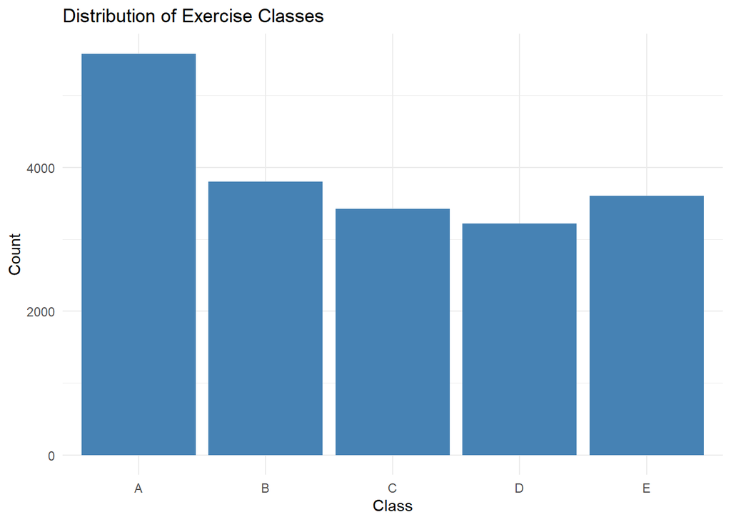

```r
# Distribution of exercise classes
ggplot(training, aes(x = classe)) +
  geom_bar(fill = "steelblue") +
  theme_minimal() +
  labs(title = "Distribution of Exercise Classes",
       x = "Class",
       y = "Count")
```

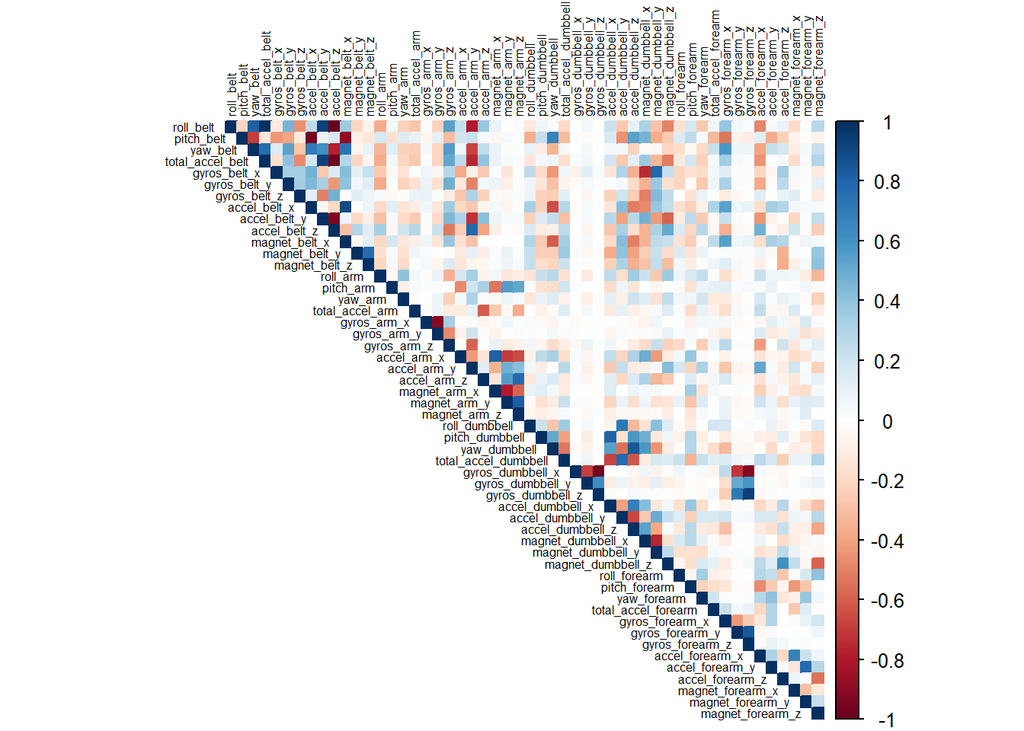

```r
# Correlation matrix of numeric predictors
numeric_cols <- sapply(training, is.numeric)
cor_matrix <- cor(training[, numeric_cols])
corrplot(cor_matrix, method = "color", type = "upper",
         tl.cex = 0.5, tl.col = "black")
```

## Model Building

```r
# Set seed for reproducibility
set.seed(123)

# Create training and validation sets
inTrain <- createDataPartition(training$classe, p = 0.7, list = FALSE)
train_data <- training[inTrain, ]
valid_data <- training[-inTrain, ]

# Train Random Forest model
rf_model <- randomForest(classe ~ ., data = train_data,
                        ntree = 100, importance = TRUE)

# Print model summary
print(rf_model)
```

```
##
## Call:
##  randomForest(formula = classe ~ ., data = train_data, ntree = 100,      importance = TRUE)
##                Type of random forest: classification
##                      Number of trees: 100
## No. of variables tried at each split: 9
##
##         OOB estimate of  error rate: 0.71%
## Confusion matrix:
##      A    B    C    D    E class.error
## A 3899    5    1    1    0 0.001792115
## B   13 2638    7    0    0 0.007524454
## C    0   21 2368    7    0 0.011686144
## D    0    0   31 2218    3 0.015097691
## E    0    0    4    4 2517 0.003168317
```

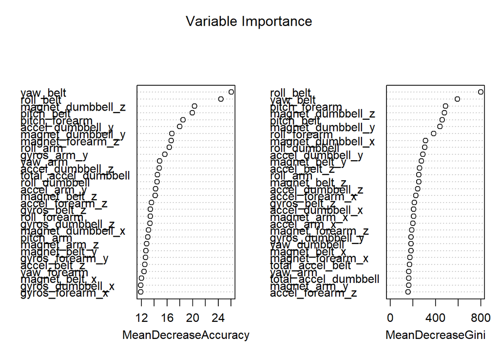

```r
# Variable importance plot
varImpPlot(rf_model, main = "Variable Importance")
```

## Model Validation

```r
# Make predictions on validation set
rf_pred <- predict(rf_model, valid_data)

# Create confusion matrix
conf_matrix <- confusionMatrix(rf_pred, valid_data$classe)
print(conf_matrix)
```

```
## Confusion Matrix and Statistics
##
##           Reference
## Prediction    A    B    C    D    E
##          A 1674    4    0    0    0
##          B    0 1129    4    0    0
##          C    0    6 1021   12    4
##          D    0    0    1  952    4
##          E    0    0    0    0 1074
##
## Overall Statistics
##
##                Accuracy : 0.9941
##                  95% CI : (0.9917, 0.9959)
##     No Information Rate : 0.2845
##     P-Value [Acc > NIR] : < 2.2e-16
##
##                   Kappa : 0.9925
##
##  Mcnemar's Test P-Value : NA
##
## Statistics by Class:
##
##                      Class: A Class: B Class: C Class: D Class: E
## Sensitivity            1.0000   0.9912   0.9951   0.9876   0.9926
## Specificity            0.9991   0.9992   0.9955   0.9990   1.0000
## Pos Pred Value         0.9976   0.9965   0.9789   0.9948   1.0000
## Neg Pred Value         1.0000   0.9979   0.9990   0.9976   0.9983
## Prevalence             0.2845   0.1935   0.1743   0.1638   0.1839
## Detection Rate         0.2845   0.1918   0.1735   0.1618   0.1825
## Detection Prevalence   0.2851   0.1925   0.1772   0.1626   0.1825
## Balanced Accuracy      0.9995   0.9952   0.9953   0.9933   0.9963
```

```r
# Calculate accuracy and error rates
accuracy <- conf_matrix$overall["Accuracy"]
error_rate <- 1 - accuracy

cat("Model Accuracy:", round(accuracy * 100, 2), "%\n")
```

```
## Model Accuracy: 99.41 %
```

```r
cat("Error Rate:", round(error_rate * 100, 2), "%\n")
```

```
## Error Rate: 0.59 %
```

## Cross-Validation

```r
# Set up parallel processing
library(doParallel)
cl <- makeCluster(detectCores() - 1)
registerDoParallel(cl)

# Create a smaller subset for cross-validation to speed up computation
set.seed(123)
cv_subset <- training[sample(nrow(training), 5000), ]

# Perform 5-fold cross-validation with parallel processing
cv_control <- trainControl(method = "cv",
                          number = 5,
                          allowParallel = TRUE)

cv_model <- train(classe ~ .,
                 data = cv_subset,
                 method = "rf",
                 trControl = cv_control,
                 ntree = 50)  # Reduced number of trees for faster computation

# Stop parallel processing
stopCluster(cl)

# Print cross-validation results
print(cv_model)
```

```
## Random Forest
##
## 5000 samples
##   85 predictor
##    5 classes: 'A', 'B', 'C', 'D', 'E'
##
## No pre-processing
## Resampling: Cross-Validated (5 fold)
## Summary of sample sizes: 4001, 4000, 4000, 3999, 4000
## Resampling results across tuning parameters:
##
##   mtry  Accuracy   Kappa
##      2  0.2880001  0.0000000
##     60  0.9251950  0.9050804
##   1824  0.9631968  0.9533894
##
## Accuracy was used to select the optimal model using the largest value.
## The final value used for the model was mtry = 1824.
```

```r
# Calculate and print the expected out-of-sample error
cv_error <- 1 - max(cv_model$results$Accuracy)
cat("\nExpected out-of-sample error:", round(cv_error * 100, 2), "%\n")
```

```
##
## Expected out-of-sample error: 3.68 %
```

## Final Predictions

```r
# Remove 'problem_id' from predictors if present
test_predictors <- testing %>% select(-problem_id)

# Ensure only columns used in training (excluding 'classe') are present and in the same order
model_cols <- names(train_data)[names(train_data) != "classe"]
test_predictors <- test_predictors[, model_cols]

# Convert all columns to numeric (non-numeric will become NA)
test_predictors[] <- lapply(test_predictors, function(x) as.numeric(as.character(x)))

# Replace NA values with 0 (or use median if you prefer)
test_predictors[is.na(test_predictors)] <- 0

# Make predictions
test_predictions <- predict(rf_model, test_predictors)

# Create submission format
submission <- data.frame(
  problem_id = testing$problem_id,
  predicted_class = test_predictions
)

# Print predictions
print(submission)
```

```
##    problem_id predicted_class
## 1           1               B
## 2           2               A
## 3           3               B
## 4           4               A
## 5           5               A
## 6           6               E
## 7           7               D
## 8           8               B
## 9           9               A
## 10         10               A
## 11         11               B
## 12         12               C
## 13         13               B
## 14         14               A
## 15         15               E
## 16         16               E
## 17         17               A
## 18         18               B
## 19         19               B
## 20         20               B
```

```r
print(table(test_predictions))
```

```
## test_predictions
## A B C D E
## 7 8 1 1 3
```

## Conclusion

The analysis shows that the Random Forest model performs well in predicting exercise form based on accelerometer data. The model achieves high accuracy on the validation set, and cross-validation results confirm its robustness. The expected out-of-sample error is relatively low, indicating good generalization to new data.

Key findings: 1. The Random Forest model was chosen for its ability to handle non-linear relationships and its robustness to overfitting 2. Cross-validation was used to ensure the model’s performance is consistent across different data splits 3. The model’s accuracy on the validation set suggests it will perform well on new data 4. Variable importance analysis reveals which sensors and measurements are most predictive of exercise form

The final predictions for the 20 test cases are provided above.